# STAT 420: Homework 04

Spring 2020, Yu Wu (yuw5)

Due: Tuesday, February 25 by 11:30 PM CT

# Assignment

## Exercise 1 (Using `lm` for Inference)

For this exercise we will again use the `faithful` dataset. Remember, this is a default dataset in `R`, so there is no need to load it. You should use `?faithful` to refresh your memory about the background of this dataset about the duration and waiting times of eruptions of [the Old Faithful geyser](http://www.yellowstonepark.com/about-old-faithful/) in [Yellowstone National Park](https://en.wikipedia.org/wiki/Yellowstone_National_Park).

**(a)** Fit the following simple linear regression model in `R`. Use the eruption duration as the response and waiting time as the predictor.

$$Y_i = \beta_0 + \beta_1 x_i + \epsilon_i$$

Store the results in a variable called `faithful_model`. Use a $t$ test to test the significance of the regression. Report the following:

- The null and alternative hypotheses
- The value of the test statistic
- The p-value of the test
- A statistical decision at $\alpha = 0.01$
- A conclusion in the context of the problem

When reporting these, you should explicitly state them in your document, not assume that a reader will find and interpret them from a large block of `R` output.

```r
data("faithful")
fit <- lm(eruptions ~ waiting, data = faithful)

summary(fit)$coefficients[2, 3]
```

```
## [1] 34.08904
```

```r
summary(fit)$coefficients[2, 4]
```

```
## [1] 8.129959e-100
```

- The null hypotheses is $\beta_1 = 0$ and alternative hypotheses is $\beta_1 \neq 0$.
- The value of the test statistic is 34.08904.
- The p-value of the test is 8.129959e-100.
- The statistical decision at $\alpha = 0.01$ is reject null hypothesis.
- The conclusion in the context of the problem is that the waiting time is a significant predictor, there is a linear relationship.

**(b)** Calculate a 99% confidence interval for $\beta_1$. Give an interpretation of the interval in the context of the problem.

```r
confint(fit, "waiting", level = 0.99)
```

```
##             0.5 %    99.5 %
## waiting 0.0698727 0.0813832
```

When waiting time increases by 1 minute, we are 99% sure that the eruption time will increase between 0.0698727 to 0.0813832 minutes.

**(c)** Calculate a 90% confidence interval for $\beta_0$. Give an interpretation of the interval in the context of the problem.

```r
confint(fit, "(Intercept)", level = 0.99)
```

```
##                 0.5 %    99.5 %
## (Intercept) -2.289453 -1.458579
```

When waiting time is at 0 minute, we are 99% sure that the eruption time will be between -2.289453 to -1.458579 minutes.

**(d)** Use a 95% confidence interval to estimate the mean eruption duration for waiting times of 75 and 80 minutes. Which of the two intervals is wider? Why?

```r
x1 <- data.frame(waiting = 75)
x2 <- data.frame(waiting = 80)
predict(fit, x1, interval = c("confidence"), level = 0.95)
```

```
##       fit      lwr      upr
## 1 3.79808 3.736159 3.860002
```

```r
predict(fit, x2, interval = c("confidence"), level = 0.95)
```

```
##       fit      lwr      upr
## 1 4.17622 4.104848 4.247592
```

```r
mean(faithful$waiting)
```

```
## [1] 70.89706
```

The interval for 80 minutes is wider because it is further away from the center.

**(e)** Use a 95% prediction interval to predict the eruption duration for waiting times of 75 and 100 minutes.

```r
x1 <- data.frame(waiting = 75)
x2 <- data.frame(waiting = 100)
predict(fit, x1, interval = c("prediction"), level = 0.95)
```

```
##       fit      lwr      upr
## 1 3.79808 2.818592 4.777569
```

```r
predict(fit, x2, interval = c("prediction"), level = 0.95)
```

```
##        fit      lwr      upr
## 1 5.688779 4.701239 6.676319
```

**(f)** Create a scatterplot of the data. Add the regression line, 95% confidence bands, and 95% prediction bands.

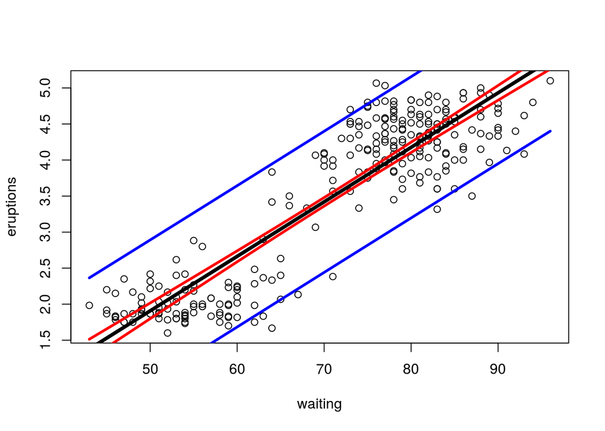

```r
x <- seq(min(faithful$waiting), max(faithful$waiting), by = 0.01)
ci <- predict(fit, newdata = data.frame(waiting = x), interval = "confidence")
pi <- predict(fit, newdata = data.frame(waiting = x), interval = "prediction")

plot(eruptions ~ waiting, data = faithful, xlab = "waiting", ylab = "eruptions")

# regression line
abline(fit, lwd = 4)

# confidence bands
lines(x, ci[,2], col = "red", lwd = 3)
lines(x, ci[,3], col = "red", lwd = 3)

# prediction bands
lines(x, pi[,2], col = "blue", lwd = 3)
lines(x, pi[,3], col = "blue", lwd = 3)
```

## Exercise 2 (Using `lm` for Inference)

For this exercise we will again use the `diabetes` dataset, which can be found in the `faraway` package.

**(a)** Fit the following simple linear regression model in `R`. Use the total cholesterol as the response and weight as the predictor.

$$Y_i = \beta_0 + \beta_1 x_i + \epsilon_i$$

Store the results in a variable called `cholesterol_model`. Use an $F$ test to test the significance of the regression. Report the following:

- The null and alternative hypotheses
- The ANOVA table (You may use `anova()` and omit the row for Total.)
- The value of the test statistic
- The p-value of the test
- A statistical decision at $\alpha = 0.05$
- A conclusion in the context of the problem

When reporting these, you should explicitly state them in your document, not assume that a reader will find and interpret them from a large block of `R` output.

```r
library(faraway)
data('diabetes')
fit <- lm(chol ~ weight, data = diabetes)
anova(fit)
```

```
## Analysis of Variance Table
##
## Response: chol
##            Df Sum Sq Mean Sq F value Pr(>F)
## weight      1   3505  3505.4  1.7932 0.1813
## Residuals 399 779991  1954.9
```

```r
summary(fit)$fstatistic[1]
```

```
##    value
## 1.793178
```

```r
summary(fit)$coefficients[2, 4]
```

```
## [1] 0.1813018
```

- The null hypotheses is $\beta_1 = 0$ and alternative hypotheses is $\beta_1 \neq 0$.
- The value of the test statistic is 1.7932.
- The anova table

```r
knitr::kable(anova(fit))
```

|  | Df | Sum Sq | Mean Sq | F value | Pr(>F) |
| --- | --- | --- | --- | --- | --- |
| weight | 1 | 3505.42 | 3505.420 | 1.793178 | 0.1813018 |
| Residuals | 399 | 779991.18 | 1954.865 | NA | NA |

- The p-value of the test is 0.1813018.
- The statistical decision at $\alpha = 0.05$ is fail to reject null hypothesis.
- The conclusion in the context of the problem is that the weight is not a significant predictor for cholesterol, there is no linear relationship bwtween cholesterol and weight.

**(b)** Fit the following simple linear regression model in `R`. Use HDL as the response and weight as the predictor.

$$Y_i = \beta_0 + \beta_1 x_i + \epsilon_i$$

Store the results in a variable called `hdl_model`. Use an $F$ test to test the significance of the regression. Report the following:

- The null and alternative hypotheses
- The ANOVA table (You may use `anova()` and omit the row for Total.)
- The value of the test statistic
- The p-value of the test
- A statistical decision at $\alpha = 0.05$
- A conclusion in the context of the problem

When reporting these, you should explicitly state them in your document, not assume that a reader will find and interpret them from a large block of `R` output.

```r
fit <- lm(hdl ~ weight, data = diabetes)
anova(fit)
```

```
## Analysis of Variance Table
##
## Response: hdl
##            Df Sum Sq Mean Sq F value    Pr(>F)
## weight      1  10100 10100.2  36.909 2.891e-09 ***
## Residuals 399 109188   273.7
## ---
## Signif. codes:  0 '***' 0.001 '**' 0.01 '*' 0.05 '.' 0.1 ' ' 1
```

```r
summary(fit)$fstatistic[1]
```

```
##    value
## 36.90875
```

```r
summary(fit)$coefficients[2, 4]
```

```
## [1] 2.890526e-09
```

- The null hypotheses is $\beta_1 = 0$ and alternative hypotheses is $\beta_1 \neq 0$.
- The value of the test statistic is 36.90875.
- The anova table

```r
knitr::kable(anova(fit))
```

|  | Df | Sum Sq | Mean Sq | F value | Pr(>F) |
| --- | --- | --- | --- | --- | --- |
| weight | 1 | 10100.22 | 10100.2217 | 36.90875 | 0 |
| Residuals | 399 | 109187.89 | 273.6539 | NA | NA |

- The p-value of the test is 2.890526e-09.
- The statistical decision at $\alpha = 0.05$ is reject null hypothesis.
- The conclusion in the context of the problem is that the weight is a significant predictor for HDL, there is a linear relationship bwtween HDL and weight.

## Exercise 3 (Inference “without” `lm`)

For this exercise we will once again use the data stored in `goalies.csv`. It contains career data for all 716 players in the history of the National Hockey League to play goaltender through the 2014-2015 season. The two variables we are interested in are:

- `W` - Wins
- `MIN` - Minutes

Fit a SLR model with `W` as the response and `MIN` as the predictor. Test $H_0: \beta_1 = 0.008$ vs $H_1: \beta_1 < 0.008$ at $\alpha = 0.01$. Report the following:

- $\hat{\beta_1}$
- $SE[\hat{\beta_1}]$
- The value of the $t$ test statistic
- The degrees of freedom
- The p-value of the test
- A statistical decision at $\alpha = 0.01$

When reporting these, you should explicitly state them in your document, not assume that a reader will find and interpret them from a large block of `R` output.

You should use `lm()` to fit the model and obtain the estimate and standard error. But then you should directly calculate the remaining values. Hint: be careful with the degrees of freedom. Think about how many observations are being used.

```r
goalies <- read.csv("goalies.csv")
fit <- lm(W ~ MIN, data = goalies)
summary(fit)
```

```
##
## Call:
## lm(formula = W ~ MIN, data = goalies)
##
## Residuals:
##     Min      1Q  Median      3Q     Max
## -81.814  -4.447   2.691   4.316 111.354
##
## Coefficients:
##               Estimate Std. Error t value Pr(>|t|)
## (Intercept) -4.402e+00  7.698e-01  -5.719 1.58e-08 ***
## MIN          7.846e-03  5.071e-05 154.724  < 2e-16 ***
## ---
## Signif. codes:  0 '***' 0.001 '**' 0.01 '*' 0.05 '.' 0.1 ' ' 1
##
## Residual standard error: 16.78 on 711 degrees of freedom
##   (3 observations deleted due to missingness)
## Multiple R-squared:  0.9712, Adjusted R-squared:  0.9711
## F-statistic: 2.394e+04 on 1 and 711 DF,  p-value: < 2.2e-16
```

```r
df <- length(fitted(fit)) - 2
beta_hat <- summary(fit)$coef[2,1]
beta_0 <- 0.008
se <- summary(fit)$coef[2,2]
t <- (beta_hat-beta_0)/se
p <- pt(t, df)

beta_hat
```

```
## [1] 0.007845997
```

```r
se
```

```
## [1] 5.070963e-05
```

```r
t
```

```
## [1] -3.036956
```

```r
df
```

```
## [1] 711
```

```r
p
```

```
## [1] 0.0012386
```

- - $\hat{\beta_1} = 0.007845997$.
- $SE[\hat{\beta_1}] = 5.070963e-05$.
- The value of the $t$ test statistic is -3.036956.
- The degrees of freedom is 711.
- The p-value of the test is 0.0012386.
- The statistical decision at $\alpha = 0.01$ is reject the null hypothesis.

## Exercise 4 (Simulating Sampling Distributions)

For this exercise we will simulate data from the following model:

$$Y_i = \beta_0 + \beta_1 x_i + \epsilon_i$$

Where $\epsilon_i \sim N(0, \sigma^2).$ Also, the parameters are known to be:

- $\beta_0 = 4$
- $\beta_1 = 0.5$
- $\sigma^2 = 25$

We will use samples of size $n = 50$.

**(a)** Simulate this model $1500$ times. Each time use `lm()` to fit a SLR model, then store the value of $\hat{\beta}_0$ and $\hat{\beta}_1$. Set a seed using **your** UIN before performing the simulation. Note, we are simulating the $x$ values once, and then they remain fixed for the remainder of the exercise.

```r
uin = 677405631
set.seed(uin)
n = 50
x = seq(0, 20, length = n)


beta_0 <- 4
beta_1 <- 0.5
sigma_square <- 25

m <- 1500
beta_0_hat <- numeric(m)
beta_1_hat <- numeric(m)

for (i in 1:m) {
  y <- beta_0 + beta_1 * x + rnorm(n, 0, sqrt(sigma_square))
  beta_0_hat[i] <- summary(lm(y ~ x))$coef[1, 1]
  beta_1_hat[i] <- summary(lm(y ~ x))$coef[2, 1]
}
```

**(b)** For the *known* values of $x$, what is the expected value of $\hat{\beta}_1$?

The expected value of $\hat{\beta_1}$ is 0.5.

**(c)** For the known values of $x$, what is the standard deviation of $\hat{\beta}_1$?

```r
Sxx <- sum((x - mean(x))^2)
sqrt(sigma_square/Sxx)
```

```
## [1] 0.120049
```

The standard deviation of $\hat{\beta}_1$ is 0.120049.

**(d)** What is the mean of your simulated values of $\hat{\beta}_1$? Does this make sense given your answer in **(b)**?

```r
mean(beta_1_hat)
```

```
## [1] 0.4982479
```

The mean of your simulated values of $\hat{\beta}_1$ is 0.4982479. It makes sense because these two values are very close.

**(e)** What is the standard deviation of your simulated values of $\hat{\beta}_1$? Does this make sense given your answer in **(c)**?

```r
sd(beta_1_hat)
```

```
## [1] 0.1218322
```

The standard deviation of your simulated values of $\hat{\beta}_1$ is 0.1218322. It makes sense because these two values are very close.

**(f)** For the known values of $x$, what is the expected value of $\hat{\beta}_0$?

The expected value of $\hat{\beta_1}$ is 4.

**(g)** For the known values of $x$, what is the standard deviation of $\hat{\beta}_0$?

```r
sqrt(sigma_square * (1/n + mean(x)^2 / Sxx))
```

```
## [1] 1.393261
```

The standard deviation of $\hat{\beta}_1$ is 1.393261.

**(h)** What is the mean of your simulated values of $\hat{\beta}_0$? Does this make sense given your answer in **(f)**?

```r
mean(beta_0_hat)
```

```
## [1] 4.019167
```

The mean of your simulated values of $\hat{\beta}_0$ is 4.019167. It makes sense because these two values are very close.

**(i)** What is the standard deviation of your simulated values of $\hat{\beta}_0$? Does this make sense given your answer in **(g)**?

```r
sd(beta_0_hat)
```

```
## [1] 1.39312
```

The standard deviation of your simulated values of $\hat{\beta}_0$ is 1.39312. It makes sense because these two values are very close.

**(j)** Plot a histogram of your simulated values for $\hat{\beta}_1$. Add the normal curve for the true sampling distribution of $\hat{\beta}_1$.

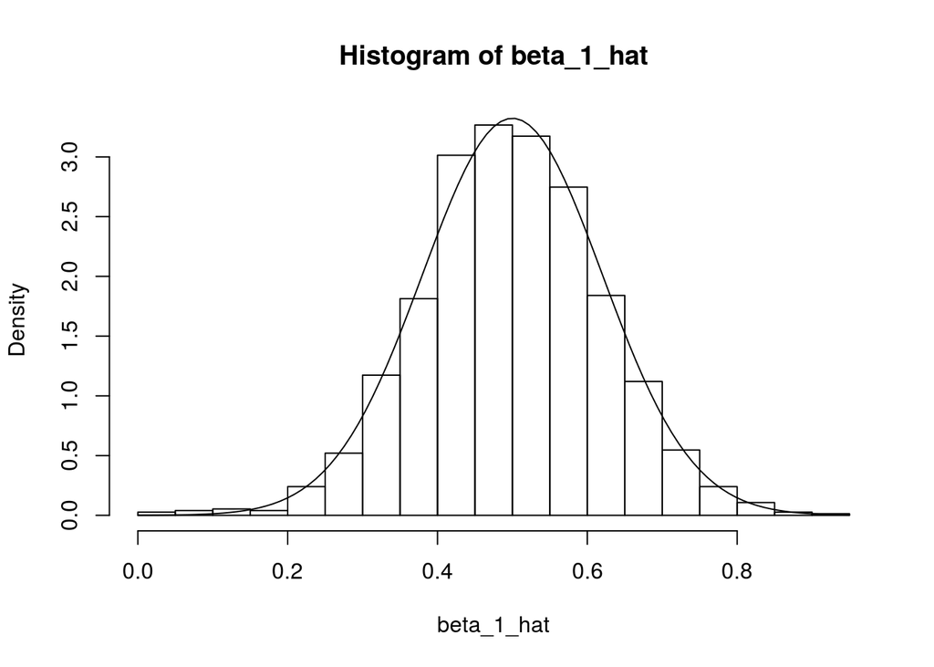

```r
hist(beta_1_hat, breaks = 20, prob = TRUE)
curve(dnorm(x, beta_1, sqrt(sigma_square/Sxx)), add = TRUE)
```

**(k)** Plot a histogram of your simulated values for $\hat{\beta}_0$. Add the normal curve for the true sampling distribution of $\hat{\beta}_0$.

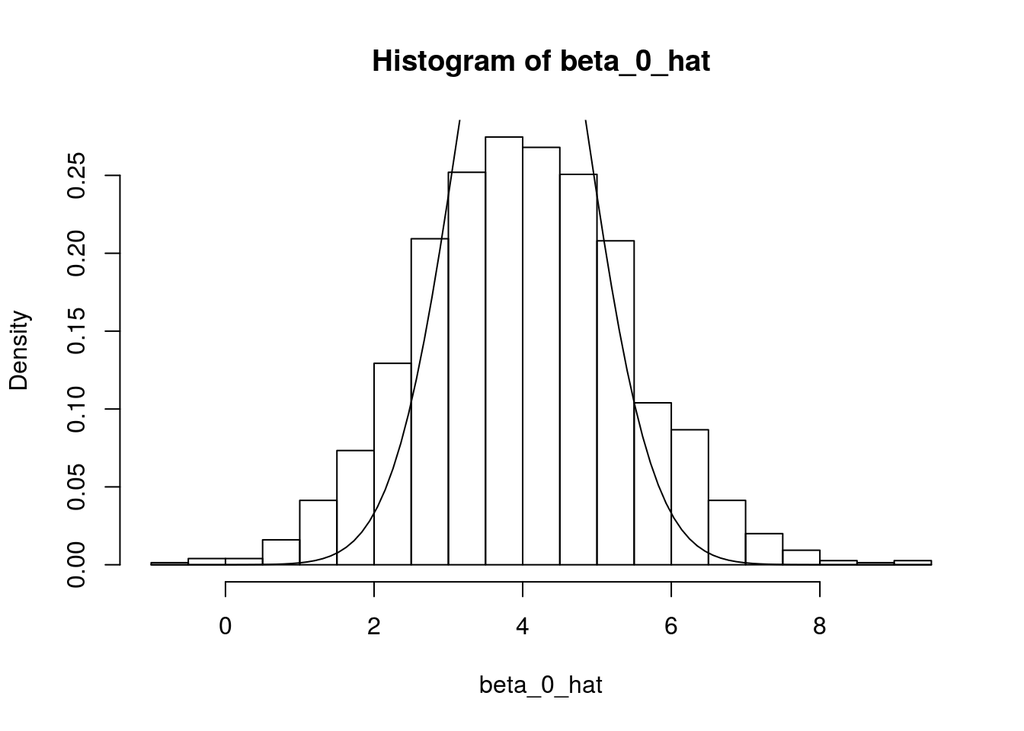

```r
hist(beta_0_hat, breaks = 20, prob = TRUE)
curve(dnorm(x, beta_0, sqrt(sigma_square * (1/n + mean(x)^2 / Sxx))), add = TRUE)
```

## Exercise 5 (Simulating Confidence Intervals)

For this exercise we will simulate data from the following model:

$$Y_i = \beta_0 + \beta_1 x_i + \epsilon_i$$

Where $\epsilon_i \sim N(0, \sigma^2).$ Also, the parameters are known to be:

- $\beta_0 = 1$
- $\beta_1 = 3$
- $\sigma^2 = 16$

We will use samples of size $n = 20$.

Our goal here is to use simulation to verify that the confidence intervals really do have their stated confidence level.

**(a)** Simulate this model $2000$ times. Each time use `lm()` to fit a SLR model, then store the value of $\hat{\beta}_0$ and $s_e$. Set a seed using **your** UIN before performing the simulation. Note, we are simulating the $x$ values once, and then they remain fixed for the remainder of the exercise.

```r
uin = 677405631
set.seed(uin)
n = 20
x = seq(-5, 5, length = n)

beta_0 <- 1
beta_1 <- 3
sigma_square <- 16

m <- 2000
beta_0_hat <- numeric(m)
se <- numeric(m)

for (i in 1:m) {
  y <- beta_0 + beta_1 * x + rnorm(n, 0, sqrt(sigma_square))
  beta_0_hat[i] <- summary(lm(y ~ x))$coef[1, 1]
  se[i] <- summary(lm(y ~ x))$sigma
}
```

**(b)** For each of the $\hat{\beta}_0$ that you simulated calculate a 90% confidence interval. Store the lower limits in a vector `lower_90` and the upper limits in a vector `upper_90`. Some hints:

- You will need to use `qt()` to calculate the critical value, which will be the same for each interval.
- Remember that `x` is fixed, so $S_{xx}$ will be the same for each interval.
- You could, but do not need to write a `for` loop. Remember vectorized operations.

```r
t <- abs(qt(0.1/2, n-2))
Sxx <- sum((x - mean(x))^2)

lower_90 <- beta_0_hat - t * se * sqrt(1/n + mean(x)^2 / Sxx)
upper_90 <- beta_0_hat + t * se * sqrt(1/n + mean(x)^2 / Sxx)
```

**(c)** What proportion of these intervals contain the true value of $\beta_0$?

```r
mean(lower_90 < 1 & 1 < upper_90)
```

```
## [1] 0.9045
```

**(d)** Based on these intervals, what proportion of the simulations would reject the test $H_0: \beta_0 = 0$ vs $H_1: \beta_0 \neq 0$ at $\alpha = 0.10$?

```r
1 - mean(lower_90 < 0 & 0 < upper_90)
```

```
## [1] 0.2825
```

**(e)** For each of the $\hat{\beta}_0$ that you simulated calculate a 99% confidence interval. Store the lower limits in a vector `lower_99` and the upper limits in a vector `upper_99`.

```r
t <- abs(qt(0.01/2, n-2))
Sxx <- sum((x - mean(x))^2)

lower_99 <- beta_0_hat - t * se * sqrt(1/n + mean(x)^2 / Sxx)
upper_99 <- beta_0_hat + t * se * sqrt(1/n + mean(x)^2 / Sxx)
```

**(f)** What proportion of these intervals contain the true value of $\beta_0$?

```r
mean(lower_99 < 1 & 1 < upper_99)
```

```
## [1] 0.9945
```

**(g)** Based on these intervals, what proportion of the simulations would reject the test $H_0: \beta_0 = 0$ vs $H_1: \beta_0 \neq 0$ at $\alpha = 0.01$?

```r
1 - mean(lower_99 < 0 & 0 < upper_99)
```

```
## [1] 0.0625
```